# Bias Reduction in TSTS(LS) Applications A Quantile Adjustment Method

Pedro Javier Torres López

Department of Social Policy & III - LSE

# Introduction

## This paper

- Income and a second variable often sit in separate samples
- Researchers predict income from the characteristics both share and use the prediction in its place
- The prediction is less dispersed than observed income
- It carries only the part of the link with the second variable that runs through the predictors
- I replace each prediction with the observed income at the same rank

**The result**

Closest to the benchmark on fourteen of nineteen estimands, and within 0.6 percentage points of the best method on the other five.

## Outline

1. **The problem** and why existing fixes are not enough
2. **The setup**, and where each distortion comes from
3. **The adjustment**, and why it moves a covariance at all
4. **How much comes back**, the recovery fraction and its regimes
5. **Two diagnostics** a researcher can compute before imputing
6. **Three applications**, Mexico, Ecuador and Chile

**Note**

Sections 3 to 5 carry the argument. The applications show that the regimes bind in practice.

## Terminology

| Term | Meaning |
| --- | --- |
| **Donor sample** | Observes income $y$ and the common predictors $\mathbf{X}$ |
| **Target sample** | Observes the external variable $z$ and $\mathbf{X}$ |
| **External variable** | Any $z$ outside the first stage, observed only in the target |
| **Baseline imputation** | Using $\hat y$ in place of $y$ with no correction |
| **Quantile gap** | $\eta(p)$, the distance between observed and predicted quantiles |
| **Recovery fraction** | $\lambda$, the share of the missing covariance put back |

**Note**

A quick reference. Each term is defined properly as it comes up.

# The Imputation Problem

## Motivation

A number of questions need income measured alongside a second variable.

- Welfare analysis needs income next to consumption
- Mobility research needs a parent’s earnings next to their child’s
- Inequality of opportunity needs income next to the circumstances a person was born into
- In many cases no single source observes both, and often none can

**Note**

I call the second variable the external variable $z$, because it sits outside the source where income is observed.

Consumption (Decancq 2014; Brewer, Etheridge, and O’Dea 2017; Donatiello et al. 2025), mobility (Solon 1992; Björklund and Jäntti 1997; Mazumder 2005), opportunity (Ferreira, Gignoux, and Aran 2011; Torres, Monroy-Gómez-Franco, and Vélez-Grajales 2025)

## Two-sample two-stage imputation (Klevmarken 1982; Inoue and Solon 2010)

Two samples, one set of common predictors $\mathbf{X}$.

- **First stage.** Fit income on $\mathbf{X}$ in the donor sample and predict into the target
- **Second stage.** Estimate the relationship of interest with the prediction in place of income

I call the uncorrected use of these predictions **baseline imputation**.

First stages beyond least squares (Bloise, Brunori, and Piraino 2021; Viljanen et al. 2022). Within-sample imputation, which needs some respondents to report income (Little 1988; Rubin 1986, 1987)

**Note**

Predictive mean matching and hot deck need some respondents to report income. Here it is missing from every row of the target.

## Two sources of bias

- Compression
- The lost link
- A predicted value averages over people with the same characteristics
- It smooths away everything the first stage cannot explain (Rubin 1976; McKenzie 2005)

$$\operatorname{Var}(y) = \operatorname{Var}(\hat y) + \operatorname{Var}(\varepsilon),
\qquad
\operatorname{Var}(\hat y) = R^2 \operatorname{Var}(y)$$

**In the applications**

Baseline imputation recovers between 48 and 65 per cent of the variance of log income.

Predicted income keeps only the part of its relationship with $z$ that runs through $\mathbf{X}$, which Cortes Orihuela et al. (2024) call projection bias.

$$\operatorname{Cov}(y, z) = \operatorname{Cov}(\hat y, z) +
\operatorname{Cov}(\varepsilon, z)$$

- Two parents with the same education and occupation who earn different amounts
- If the higher earner also has higher-earning children, that link goes with the prediction

**In the applications**

Baseline imputation recovers between 58 and 78 per cent of the covariance with the external variable.

## Bias channels by estimand

| Group | Estimand | Variance | Covariance |
| --- | --- | --- | --- |
| Marginal distribution | Poverty rates, Gini, MLD | Present | Absent |
| Joint distribution (A) | IGE, income-consumption correlation | Present | Present |
| Joint distribution (B) | IOp circumstance coefficients | Absent | Present |

Group B carries no variance channel because $\operatorname{Var}(\mathbf{Z})$, not $\operatorname{Var}(y)$, sits in the denominator.

Poverty (Elbers, Lanjouw, and Lanjouw 2003; Sinha Roy and Weide 2022), inequality indices (Ferreira, Gignoux, and Aran 2011; Betti, Molini, and Mori 2024), elasticities (Björklund and Jäntti 1997; Mazumder 2005), correlations (Decancq 2014; Fasianos and Lydon 2021), opportunity (Ferreira and Gignoux 2011; Torres, Monroy-Gómez-Franco, and Vélez-Grajales 2025)

**Note**

The estimand decides which channel matters, so it should also decide the method.

## Existing corrections

- For the variance
- For the covariance
- The risk

Stochastic augmentation adds a random draw from the donor residuals to each prediction (Rubin 1976; McKenzie 2005; Dang 2021).

$$\tilde y_s = \hat y + \tilde\varepsilon, \qquad
\tilde\varepsilon \perp\!\!\!\perp \mathbf{X}$$

- It restores the variance
- Drawing residuals and exponentiating performs Duan’s smearing implicitly (Duan 1983), so the conditional mean in levels comes back under homoskedastic log errors
- The draws have nothing to do with $z$, so $\operatorname{Cov}(\tilde\varepsilon, z) = 0$
- The covariance stays where baseline imputation left it

It restores the variance but not the tails, to which inequality indices are sensitive (Atkinson 1970; Cowell 2011; Betti, Molini, and Mori 2024), so headcounts come back more accurately than inequality measures (Demombynes et al. 2007)

- Crossley, Levell, and Poupakis (2022) show that regression-based and matching-based imputation give inconsistent second-stage estimates, and propose rescaled regression prediction
- Cortes Orihuela et al. (2024) combine the two corrections for the intergenerational elasticity
- Both act on the estimand rather than on the imputed values, so each has to be derived again for the next one
- Ratio estimands carry both distortions, and they partly cancel
- Removing one leaves the other fully exposed

The Mexican correlation under each method,

| Method | Bias ratio |
| --- | --- |
| Baseline | 0.84 |
| Stochastic augmentation | 0.58 |

Fixing the variance alone does worse than doing nothing.

## Contribution

**Research question**

Can one correction address both distortions at once, act on the imputed values rather than on the estimand, and tell the researcher in advance when it will help?

**The answer**

Yes for the first two, by construction. The third is a matter of degree, and the rest of the talk is about measuring it.

# Setup and Notation

## Donor and target samples

- **Donor sample.** $n_d$ draws from $(y, \mathbf{X})$, where $z$ is unobserved
- **Target sample.** $n_t$ draws from $(z, \mathbf{X})$, where $y$ is unobserved
- Both are random draws from the same population
- $\mathbf{X}$ holds meaningful predictors of $y$

**Note**

In the intergenerational case the target records offspring income $z$ with parental background $\mathbf{X}$, and a second survey observes parental income $y$ with the same background variables.

## First-stage imputation

At the population level income decomposes as

$$y = f(\mathbf{X}) + \varepsilon, \qquad
f(\mathbf{X}) := \mathbb{E}[y \mid \mathbf{X}], \qquad
\mathbb{E}[\varepsilon \mid \mathbf{X}] = 0$$

and the imputed outcome is the population prediction $\hat y = f(\mathbf{X})$.

**Note**

In practice $f$ is unknown, the researcher assumes a form, usually log-linear, and estimates it on the donor sample.

## Berkson measurement error (Berkson 1950; Bound, Brown, and Mathiowetz 2001)

- Classical measurement error is independent of the true variable
- Berkson error is mean-independent of the measured one

$$y = \hat y + \varepsilon, \qquad \mathbb{E}[\varepsilon \mid \hat y] = 0$$

The second condition follows because $\hat y$ is a deterministic function of $\mathbf{X}$.

**The gap that matters**

$\mathbb{E}[\varepsilon \mid \mathbf{X}] = 0$ by construction, but nothing forces $\mathbb{E}[\varepsilon \mid z] = 0$. What $\mathbf{X}$ leaves unexplained can still move with $z$.

## Three classes of estimand

- Marginal
- Ratios
- Coefficients

$$I(y), \qquad \text{poverty headcounts}$$

Depend on the imputed distribution alone. Only compression reaches them.

$$\rho_{y,z} = \frac{\operatorname{Cov}(y,z)}{\sigma_y \sigma_z},
\qquad
\beta_{\text{IGE}} = \frac{\operatorname{Cov}(y,z)}{\operatorname{Var}(y)}$$

Both channels enter, and they work against each other.

$$\delta = \frac{\operatorname{Cov}(y, z)}{\operatorname{Var}(z)}$$

Imputation leaves $\operatorname{Var}(z)$ untouched, so only the covariance channel enters.

**Why act on the values**

A correction applied to the imputed values serves all three without a derivation for each.

# The Quantile Adjustment

## The quantile gap

- Definition
- Construction

Let $Q_y(p)$ and $Q_{\hat y}(p)$ be the quantile functions of observed and predicted income. Define

$$\eta(p) := Q_y(p) - Q_{\hat y}(p).$$

- Compression puts $Q_{\hat y}$ above $Q_y$ at low $p$ and below it at high $p$
- So $\eta$ is negative in the lower tail and positive in the upper

**Note**

The gap is a property of the two distributions, not of any one observation.

[interactive chart not shown]

## The adjustment

Each observation receives the gap at its own position in the predicted distribution,

$$\tilde y_q = \hat y + \tilde\eta,
\qquad
\tilde\eta := \eta(p),
\qquad
p = F_{\hat y}(\hat y).$$

Since $\hat y = Q_{\hat y}(p)$ at that position,

$$\tilde y_q = Q_{\hat y}(p) + \eta(p) = Q_y(p).$$

**In words**

An observation at the 90th percentile of predicted income receives the income found at the 90th percentile of observed income.

## Variance bias correction

When $\hat y$ is continuous, $p$ is uniform, so $\tilde y_q$ has the distribution of $y$ exactly.

- The variance comes back, and so do the higher moments and the tails
- Any inequality index computed from the adjusted values comes back with them
- The second stage never has to know a correction took place

**Scale invariance**

Exponentiation leaves ranks unchanged, so values computed in logs and then exponentiated coincide with values computed in levels. A log first stage would otherwise need Duan’s smearing before any level-scale estimand, and here no retransformation arises at any point.

Appendix: Smearing and retransformation

Tail-sensitive indices (Atkinson 1970; Cowell 2011). Retransformation under a log first stage (Duan 1983; Manning 1998; Manning and Mullahy 2001)

## The adjustment and the prediction error

- $\tilde\eta$ is the gap at a position, not the prediction error put back
- By Berkson, the error averages zero at every position

[interactive chart not shown]

**Caution**

Every observation at a given position receives the same adjustment, whatever its own income or its own $z$.

## Covariance bias correction

By linearity,

$$\operatorname{Cov}(\tilde y_q, z) = \operatorname{Cov}(\hat y, z) +
\operatorname{Cov}(\tilde\eta, z).$$

[interactive chart not shown]

**Tip**

An upward-sloping line is a positive shift. The next section is about its size.

## Sign of the adjustment

- The group the prediction puts at the bottom earns, on average, what was predicted for it
- The group that actually earns least earns less still

$$\operatorname{Cov}(\hat y, \tilde\eta) \geq 0$$

- I prove it through $H(p) = \int_0^p \eta(s)\,ds$, the gap between two generalised Lorenz curves
- $H$ is zero at both ends and never positive in between

**Note**

Only the running total enters, so the quantile gap itself may rise and fall along the distribution. Ecuador’s does.

Appendix: The sign result

# Recovery of the Covariance

## The recovery fraction

When $\operatorname{Cov}(\varepsilon, z) \neq 0$, define

$$\lambda := \frac{\operatorname{Cov}(\tilde\eta, z)}{\operatorname{Cov}(\varepsilon, z)},
\qquad\text{so}\qquad
\operatorname{Cov}(\tilde y_q, z) = \operatorname{Cov}(\hat y, z) +
\lambda \operatorname{Cov}(\varepsilon, z).$$

$\lambda$ is the fraction of the omitted covariance that the adjustment puts back. It can take any sign and any magnitude.

**Note**

Baseline imputation and stochastic augmentation are both the case $\lambda = 0$.

## Predictor and error channels

Split $z$ into the part the predictors explain and the part they do not, $z = g(\mathbf{X}) + z_\perp$.

$$\operatorname{Cov}(\tilde{\eta}, z)
= \underbrace{\operatorname{Cov}(\tilde{\eta}, g(\mathbf{X}))}_{\text{predictor channel}}
+ \underbrace{\operatorname{Cov}(\tilde{\eta}, z_{\perp})}_{\text{error channel} \; = \; 0}$$

- $\tilde\eta$ depends on $\mathbf{X}$ only through the rank of $\hat y$
- $z_\perp$ is uncorrelated with any function of $\mathbf{X}$

**Limitation**

The adjustment cannot reach the part of $z$ the predictors miss, which is exactly the part baseline imputation discards. It replaces covariance from the explained part instead.

## The magnitude of $\lambda$

Only the variation in $g(\mathbf{X})$ that tracks predicted income contributes, through $\bar g(t) := \mathbb{E}[g(\mathbf{X}) \mid \hat y = t]$.

$$\lambda = \frac{\kappa}{\rho} \cdot
\frac{\sigma_{\tilde\eta}}{\sigma_\varepsilon} \cdot
\frac{\sigma_{g(\mathbf{X})}}{\sigma_{z_{\perp}}},
\qquad
\kappa := \operatorname{Corr}(\tilde\eta, g(\mathbf{X})),
\quad
\rho := \operatorname{Corr}(\varepsilon, z_{\perp}).$$

- How well the adjustment tracks the predictable part of $z$
- The size of the adjustment against the error it stands in for
- How much of $z$ the predictors explain against what they leave behind

**Note**

$\bar g$ nondecreasing in $\hat y$ gives a predictor channel that cannot be negative, and the sign reverses when $\bar g$ decreases.

## Recovery regimes

- Partial ($0 < \lambda < 1$)
- Over-recovery ($\lambda > 1$)
- Mis-recovery ($\lambda < 0$)
- The predictors and the channels they miss pull income and $z$ the same way
- The adjustment supplies less than the first stage omitted
- Parental education predicts higher offspring income, and whatever else links parent to child does too

**Note**

The residual bias keeps the sign of the baseline bias, attenuated by $1-\lambda$.

- Same direction, but the adjustment supplies more than was omitted
- The imputed covariance crosses the truth
- Predictors strongly related to $z$ that add little to the prediction of income produce this
- They raise $\operatorname{Cov}(\hat y, z)$ and shrink what is left to recover

**Caution**

This is what the screening diagnostic is for.

- The predictors point one way and the channels they miss point the other
- The adjustment then supplies covariance of the wrong sign

Impute husbands’ earnings to study wives’ earnings,

- Men whose characteristics predict high earnings marry women who earn more (Eika, Mogstad, and Zafar 2019)
- Within a group of similar men, wives work less when husbands earn more than predicted (Devereux 2004; Blau and Kahn 2007)

**Caution**

The baseline bias is enlarged by $1 + |\lambda|$.

## Relative bias and the bound at $\lambda = 2$

Subtracting the truth from both sides leaves

$$\frac{\big|\operatorname{Cov}(\tilde y_q, z) - \operatorname{Cov}(y, z)\big|}
{\big|\operatorname{Cov}(\hat y, z) - \operatorname{Cov}(y, z)\big|} = |1 - \lambda|.$$

[interactive chart not shown]

**Tip**

The adjustment improves on baseline imputation for any $0 < \lambda < 2$. Over-recovery is not by itself a failure.

## The sign under linearity

Under three conditions, linear $\hat y$, linear $g(\mathbf{X})$, and $\bar g$ linear in predicted income,

$$\operatorname{sign}\Big[\operatorname{Cov}\big(\tilde\eta, g(\mathbf{X})\big)\Big]
= \operatorname{sign}\Big[\boldsymbol{\gamma}'\Sigma\boldsymbol{\beta}\Big],
\qquad \Sigma := \operatorname{Var}(\mathbf{X}).$$

- Every term is estimated already, $\hat{\boldsymbol\beta}$ in the donor and $\hat{\boldsymbol\gamma}$ in the target
- With one predictor the channel takes the sign of $\gamma\beta$, not of $\gamma$ alone

**Note**

Joint normality of $\mathbf{X}$ is sufficient for the third condition. The applications use mostly categorical predictors, so it holds only approximately.

Linear conditional expectations under joint normality (Anderson 2003), extending to the elliptical family (Cambanis, Huang, and Simons 1981)

## Multiple external variables

$z$ takes no part in estimating $f$ or in constructing $\eta$, so a single $\tilde\eta$ serves however many external variables the researcher has, each with its own

$$\lambda_j = \frac{\operatorname{Cov}(\tilde\eta, z_j)}{\operatorname{Cov}(\varepsilon, z_j)}.$$

An estimand that combines several covariances is different. For a regression on $\mathbf{Z}$,

$$\frac{\delta_{j,\text{TSTS}}}{\delta_{j,\text{benchmark}}} =
\frac{\sum_k w_{jk}\left[\operatorname{Cov}(\hat y, z_k) +
\lambda_k \operatorname{Cov}(\varepsilon, z_k)\right]}
{\sum_k w_{jk}\operatorname{Cov}(y, z_k)}.$$

**Caution**

Every recovery fraction enters every coefficient, so even $\lambda_j = 1$ leaves the coefficient on $z_j$ carrying the errors of the others. Correcting one coefficient at a time cannot work.

# Diagnostics

## Model selection and regime assessment

$\lambda$ depends on $\operatorname{Cov}(\varepsilon, z)$, and the part of income the predictors miss is never observed.

Both diagnostics can be computed before imputing.

1. A **screen** that flags predictors pushing the adjustment toward overshooting
2. A **threshold** that says how strong the residual dependence would have to be for exact recovery

**Note**

Maximising first-stage $R^2$ is not the objective here, which is why the specification needs a check of its own.

## The selectivity ratio

For predictor $i$ and external variable $z_k$,

$$S_i(z_k) = \frac{R^2_{z_k,t}(\mathbf{X}) - R^2_{z_k,t}(\mathbf{X}_{-i})}
{R^2_{y,d}(\mathbf{X}) - R^2_{y,d}(\mathbf{X}_{-i})}.$$

- A large ratio marks a predictor that explains $z_k$ while adding little to the explanation of income
- Drop the predictor attaining $\max_{i,k} S_i(z_k)$ while any pair exceeds $\tau$, then recompute
- Default $\tau = 10$, and a predictor flagged for any $z_k$ goes for all of them

**Note**

Offspring gender in a mobility application. It predicts offspring income through labour-market gaps and says nothing about a parent’s earnings history.

Appendix: Screening thresholds, Screening output

## The threshold correlation

Set $\lambda = 1$ and solve for the residual correlation,

$$\rho^* = \frac{\widehat{\operatorname{Cov}}(\tilde\eta_t, z_t)}
{\hat\sigma_{\varepsilon,d}\,\hat\sigma_{z_\perp,t}},
\qquad\text{and}\qquad
\lambda = \frac{\rho^*}{\rho}.$$

- The researcher never sees $\rho$, so she weighs $\rho^*$ against theory and prior evidence

| Judgement about $\|\rho\|$ | Regime |
| --- | --- |
| Above $\|\rho^*\|$, same sign | Partial covariance adjustment |
| Between $\|\rho^*\|/2$ and $\|\rho^*\|$ | Over-recovery, still an improvement |
| At or below $\|\rho^*\|/2$ | $\lambda \geq 2$, no better than doing nothing |
| Opposite sign | Mis-recovery |

**Tip**

This turns an unobservable into a question a researcher can actually argue about.

## The algorithm

1. Reweight the donor sample if the covariate distributions differ
2. Screen predictors with $S_i(z_k)$, one at a time, until none exceeds $\tau$
3. Estimate $\hat f(\cdot)$ in the donor sample on the survivors
4. Estimate $\hat\eta(p)$ on a grid and smooth it with a spline
5. Predict into the target, assign positions, compute $\tilde\eta_t = \hat\eta(p_t)$
6. Compute $\rho^*$ and weigh it against prior evidence
7. Form $\tilde y_t = \hat y_t + \tilde\eta_t$

**Implementation**

The `tstsqa` package in R implements each step, at github.com/PedroToL/tstsqa.

## Practical limitations

- Bunching
- Common support
- Different populations
- When $\mathbf{X}$ is discrete or low-dimensional, many individuals share a predicted value
- Over that interval $\hat Q_{\hat y}$ is flat while $\hat Q_y$ keeps rising
- All tied observations receive the same adjustment, and the mass point survives

**Note**

The fix is a richer prediction model. Where that is not available, inspect $\hat\eta(p)$ directly.

- Each target observation takes its adjustment off the donor’s quantile gap
- Target predictions therefore have to lie inside the donor’s predicted support
- Outside it the position sits at the boundary and the adjustment extrapolates
- Where donor and target covariate distributions differ, reweight the donor first
- Inverse probability weighting (DiNardo, Fortin, and Lemieux 1996) or entropy balancing (Hainmueller 2012)
- Fit the first stage with the same weights

# Empirical Validation

## Validation design

Comparing methods needs a setting where the answer is known.

- Split one dataset that observes $y$ and $z$ jointly into a donor and a target, with no observation in both
- The full sample plays the population, and its estimate is the **benchmark**
- Repeat 1,000 times, redrawing donor and target together

$$\text{BR}_a(\theta) = \frac{\theta(\tilde y_a, z)}{\theta(y, z)},
\qquad a \in \{\text{baseline}, \text{stochastic}, \text{quantile}\}$$

**Interpretation**

The spread measures how much each method moves when donor and target are redrawn. It is not a standard error for the estimand.

Appendix: The split design, Weighting

## Three applications

| Application | Estimand | Position of $\tilde y$ |
| --- | --- | --- |
| **Mexico**, ENIGH 2024 | Income-consumption correlation | Symmetric with $z$ |
| **Ecuador**, administrative records | Intergenerational elasticity | Right-hand side |
| **Chile**, CASEN 2015 | IOp coefficients and indices | Left-hand side |

- Together they cover every position imputed income can take in a second stage
- Chile adds a vector of external variables rather than a single one

**Note**

Because the full sample observes both variables, I can report the realised $\lambda$ next to the $\rho^*$ a researcher would have had.

## Mexico: data and benchmark

$n = 91{,}242$ households, nine candidate predictors, income and consumption in logs. Each replicate draws 50,000 households and splits them 30,000 donor and 20,000 target.

Benchmark values on the full working sample:

$$\operatorname{Var}(\log y) = 0.525,
\qquad
\operatorname{Cov}(\log y, \log z) = 0.395,
\qquad
\rho = 0.737$$

**Note**

No predictor exceeds $\tau = 10$, so all nine survive the screen. The largest mean ratio is the share of female members, at 7.87.

## Mexico: regime diagnostics

- First stage $R^2 = 0.479$, threshold $\rho^* = 0.341$
- The question is whether what the predictors leave unexplained in income still moves with consumption
- What they miss about income is more likely persistent than transitory
- Consumption tracks permanent income rather than observed characteristics alone
- So I expect a residual correlation above 0.341

**Realised regime**

The realised $\rho = 0.557$, above the threshold and of the same sign. Partial covariance adjustment, with $\lambda = 0.612$.

Appendix: Regime diagnostics

Consumption tracks permanent income rather than observed characteristics alone (Friedman 1957; Hall 1978; Blundell, Pistaferri, and Preston 2008)

## Mexico: results

- Estimates
- Bias ratios
- Quantile gap
- Densities

|  | Benchmark | Baseline | Stochastic | Quantile |
| --- | --- | --- | --- | --- |
| $\operatorname{Var}(y)$ | 0.525 | 0.252 | 0.525 | 0.522 |
| $\operatorname{Cov}(y,z)$ | 0.395 | 0.230 | 0.230 | 0.331 |
| $\rho_{y,z}$ | 0.737 | 0.619 | 0.429 | 0.619 |

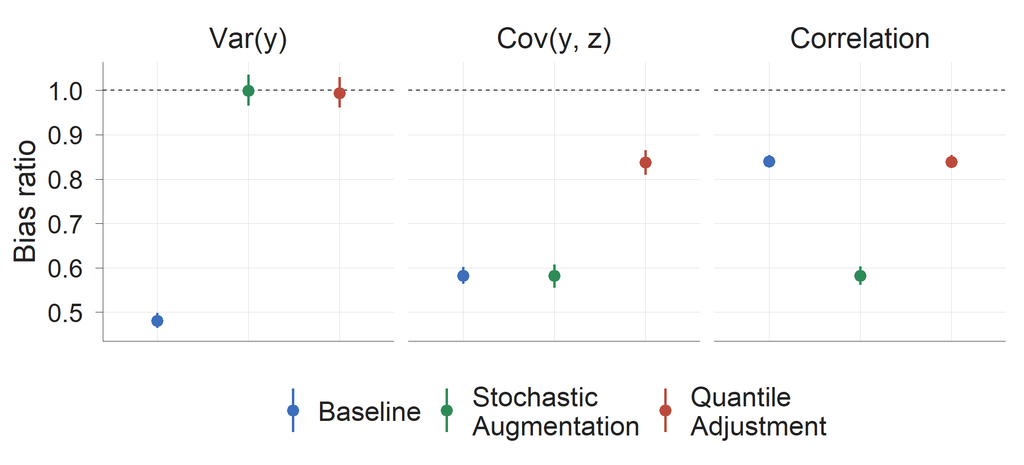

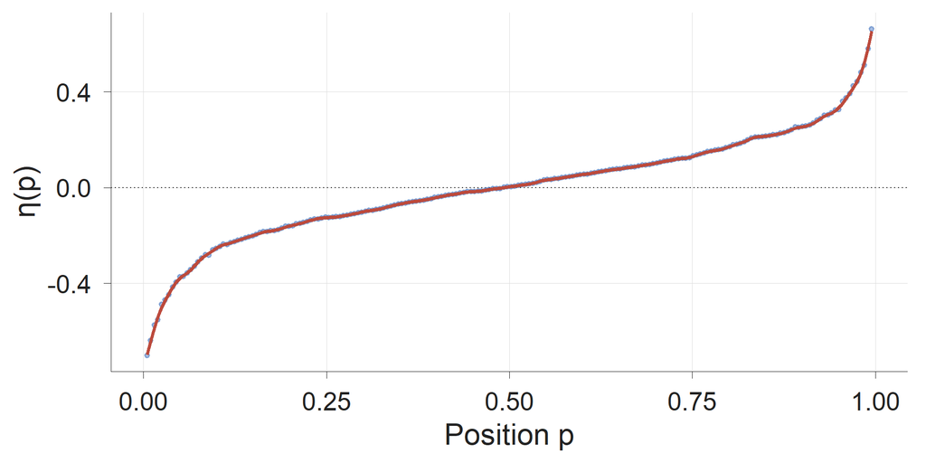

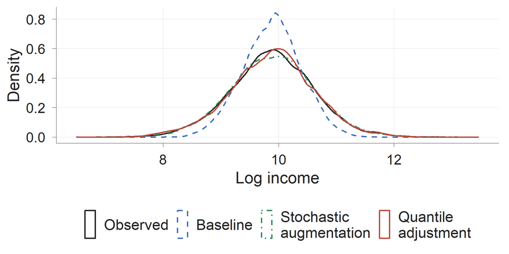

## Mexico: interpretation

- **Covariance.** Baseline recovers 58 per cent, and the adjustment puts back $\lambda = 0.612$ of the remaining 42, so $0.582 + 0.612 \times 0.418 = 0.838$
- **Correlation.** Baseline is 42 per cent short on the covariance and 44 per cent long on the ratio of standard deviations
- The two nearly offset at 16 per cent below the benchmark
- The adjustment removes both and also lands 16 per cent below

**Caution**

Two methods agreeing to a tenth of a percentage point through completely different mechanisms. I come back to this.

## Ecuador: data and benchmark

- $n = 281{,}468$ parent-offspring pairs from administrative records
- Six parental predictors, permanent parental income (Mazumder 2005)

$$\beta_{\text{IGE}} = \frac{\operatorname{Cov}(y, z)}{\operatorname{Var}(y)},
\qquad
\frac{\beta_{\text{baseline}}}{\beta_{\text{benchmark}}} = \frac{1-s}{R^2}$$

- Attenuation shrinks the numerator, compression the denominator
- So baseline imputation overstates whenever $R^2 < 1-s$

**Note**

$\rho^* = 0.152$ against a realised $\rho = 0.175$. Partial covariance adjustment, $\lambda = 0.868$.

Appendix: Ecuador: rank-rank slope, provisional screening

The intergenerational elasticity (Solon 1992; Björklund and Jäntti 1997; Cortes Orihuela et al. 2024)

## Ecuador: results

- Estimates
- Bias ratios
- Quantile gap
- Densities

|  | Benchmark | Baseline | Stochastic | Quantile |
| --- | --- | --- | --- | --- |
| $\operatorname{Var}(y)$ | 0.644 | 0.417 | 0.644 | 0.644 |
| $\operatorname{Cov}(y,z)$ | 0.258 | 0.202 | 0.202 | 0.251 |
| $\rho_{y,z}$ | 0.415 | 0.403 | 0.324 | 0.403 |
| $\beta_{\text{IGE}}$ | 0.401 | 0.484 | 0.313 | 0.389 |

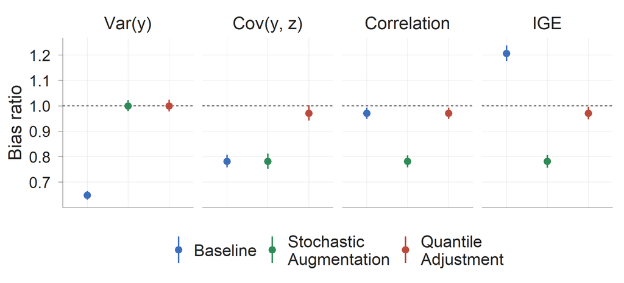

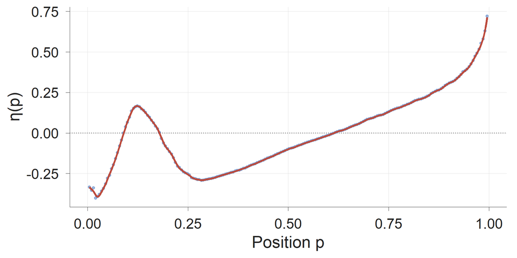

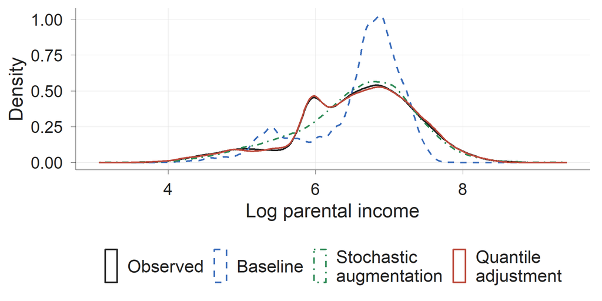

## Ecuador: interpretation

- Baseline imputation overstates the elasticity by 20.6 per cent, since its covariance shortfall of 21.8 is smaller than its variance shortfall of 35.2
- An elasticity that overstates persistence understates mobility
- Stochastic augmentation removes the compression and leaves the attenuation, ending 21.9 per cent below, slightly worse than doing nothing
- The adjustment lands 2.9 per cent below, as $1 - 0.218 \times (1 - 0.868) = 0.971$ implies

**Tip**

It does this even though the Ecuadorian quantile gap is not monotone. Only the running total has to behave.

## Chile: data and estimands

- CASEN 2015, $n = 98{,}950$ observations, six candidate predictors
- Four binary circumstances, so the regression carries a vector
- Income is now the dependent variable, and the estimands include inequality indices

$$\boldsymbol{\delta}, \qquad I(y), \qquad I(y_{|\mathbf{z}}), \qquad
\theta = \frac{I(y_{|\mathbf{z}})}{I(y)}$$

**Note**

The screen removes two predictors, both flagged against the respondent’s sex. The share of male household members goes first, at $S = 6.9 \times 10^{7}$, because it adds almost nothing to the first-stage $R^2$.

Inequality of opportunity (Roemer and Trannoy 2016), the parametric ex ante estimator (Ferreira and Gignoux 2011; Ferreira, Gignoux, and Aran 2011), and an earlier imputation-based application (Torres, Monroy-Gómez-Franco, and Vélez-Grajales 2025)

## Chile: regime diagnostics

| Circumstance | $\rho^*$ | $\rho$ | $\lambda$ | Regime |
| --- | --- | --- | --- | --- |
| Respondent male | 0.056 | 0.044 | 1.282 | Over-recovery |
| Indigenous | $-0.034$ | $-0.064$ | 0.539 | Partial |
| Father secondary or more | 0.141 | 0.172 | 0.819 | Partial |
| Mother secondary or more | 0.130 | 0.132 | 0.986 | Partial |

- The three I expected to fall in partial covariance adjustment did
- The respondent’s sex, which I left open, over-recovers

**Caution**

Household income is pooled, so sex carries little information about it once composition is in the specification. The omitted covariance is small enough that the adjustment overfills it.

## Chile: results

- Coefficients
- Inequality
- Bias ratios
- Indices

|  | Benchmark | Baseline | Stochastic | Quantile |
| --- | --- | --- | --- | --- |
| $\delta_{\text{Male}}$ | 0.177 | 0.131 | 0.131 | 0.193 |
| $\delta_{\text{Indigenous}}$ | $-0.257$ | $-0.144$ | $-0.143$ | $-0.196$ |
| $\delta_{\text{Father}}$ | 0.610 | 0.363 | 0.364 | 0.533 |
| $\delta_{\text{Mother}}$ | 0.396 | 0.291 | 0.290 | 0.445 |

|  | Benchmark | Baseline | Stochastic | Quantile |
| --- | --- | --- | --- | --- |
| $I(y)$ | 0.482 | 0.320 | 0.451 | 0.478 |
| $I(y_{\mid \mathbf{z}})$ | 0.161 | 0.098 | 0.098 | 0.154 |
| $\theta$ | 0.334 | 0.307 | 0.218 | 0.323 |

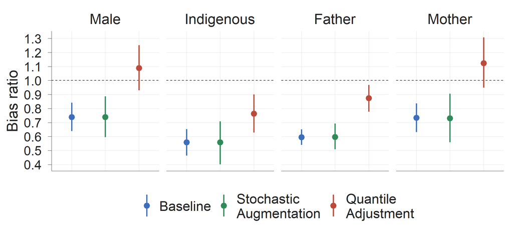

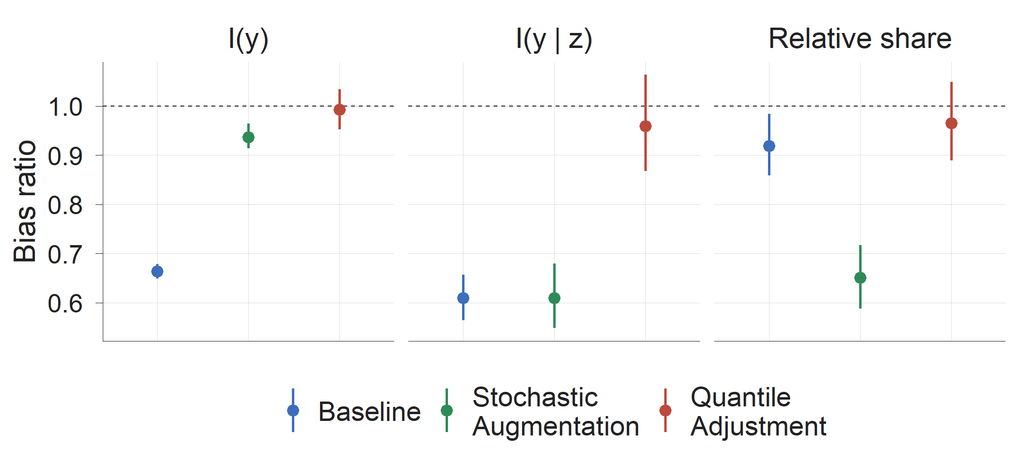

## Chile: circumstance coefficients

**Source of the error**

Appendix: Chile: variance and covariances

## Chile: inequality measures

|  | Baseline | Stochastic | Quantile |
| --- | --- | --- | --- |
| $I(y)$ | $-33.7\%$ | $-6.4\%$ | $-0.7\%$ |
| $I(y_{\mid \mathbf{z}})$ | $-39.0\%$ | $-39.0\%$ | $-4.1\%$ |
| $\theta$ | $-8.1\%$ | $-34.9\%$ | $-3.5\%$ |

- The Gini is level-scale, so the retransformation matters here
- Baseline needs Duan’s smearing applied, stochastic performs it implicitly, the adjustment needs none

**The relative share**

Baseline imputation does well on $\theta$ only because its two errors cancel.

Appendix: Smearing and retransformation

Transfer-principle indices are Schur-convex (Marshall, Olkin, and Arnold 2011)

## Relative bias by estimand

| Application | Estimand | Baseline | Stochastic | Quantile |
| --- | --- | --- | --- | --- |
| Mexico | $\operatorname{Var}(y)$ | $-52.0$ | $\mathbf{-0.0}$ | $-0.6$ |
|  | $\operatorname{Cov}(y,z)$ | $-41.8$ | $-41.8$ | $\mathbf{-16.3}$ |
|  | $\rho_{y,z}$ | $\mathbf{-16.0}$ | $-41.8$ | $-16.1$ |
| Ecuador | $\operatorname{Var}(y)$ | $-35.2$ | $\mathbf{-0.0}$ | $0.0$ |
|  | $\operatorname{Cov}(y,z)$ | $-21.8$ | $-21.9$ | $\mathbf{-2.9}$ |
|  | $\rho_{y,z}$ | $\mathbf{-2.9}$ | $-21.9$ | $-2.9$ |
|  | $\beta_{\text{IGE}}$ | $20.6$ | $-21.9$ | $\mathbf{-2.9}$ |
| Chile | $\operatorname{Var}(y)$ | $-51.9$ | $\mathbf{-0.0}$ | $-0.2$ |
|  | $\operatorname{Cov}(y,\text{Male})$ | $-26.9$ | $-27.0$ | $\mathbf{7.7}$ |
|  | $\operatorname{Cov}(y,\text{Indigenous})$ | $-42.3$ | $-42.3$ | $\mathbf{-19.5}$ |
|  | $\operatorname{Cov}(y,\text{Father})$ | $-37.1$ | $-37.1$ | $\mathbf{-6.6}$ |
|  | $\operatorname{Cov}(y,\text{Mother})$ | $-33.6$ | $-33.7$ | $\mathbf{-0.3}$ |
|  | $\delta_{\text{Male}}$ | $-26.1$ | $-26.2$ | $\mathbf{8.9}$ |
|  | $\delta_{\text{Indigenous}}$ | $-44.1$ | $-44.1$ | $\mathbf{-23.6}$ |
|  | $\delta_{\text{Father}}$ | $-40.5$ | $-40.4$ | $\mathbf{-12.6}$ |
|  | $\delta_{\text{Mother}}$ | $-26.7$ | $-27.0$ | $\mathbf{12.4}$ |
|  | $I(y)$ | $-33.7$ | $-6.4$ | $\mathbf{-0.7}$ |
|  | $I(y_{\mid \mathbf{z}})$ | $-39.0$ | $-39.0$ | $\mathbf{-4.1}$ |
|  | $\theta$ | $-8.1$ | $-34.9$ | $\mathbf{-3.5}$ |

**Tip**

Smallest absolute relative bias in bold. The adjustment wins fourteen, and the five exceptions are the three variances and the two correlations, where it trails by at most 0.6 points.

Appendix: Bias and variation across replicates

# Discussion

## Rescaling and ratio estimands

- Baseline imputation and the adjustment agree on the Mexican correlation to a tenth of a point
- That is no sign that either is right
- Suppose the two distributions have the same shape and differ only in spread
- The adjustment is then a stretch about the common mean by $1/r$, with $r = \sigma_{\hat y}/\sigma_y$

**Note**

A stretch multiplies the covariance and the standard deviation by the same factor, so a correlation cannot move under it.

Appendix: Equal shapes and the stretch

## Shape differences and the correlation

When shapes differ, the change in the correlation is

$$\frac{\operatorname{Cov}\big(R(\hat y), z\big)}{\sigma_y \sigma_z},$$

so a shape difference is necessary for the correlation to move and not sufficient.

- **Ecuador.** A shape term six times Mexico’s, and the correlation still stays put
- **Mexico in levels.** Shapes differ, and the correlation moves away from the benchmark

**Tip**

Both distributions sit in the donor sample, so standardise and compare them before imputing.

Appendix: Mexico: estimands in levels

## Scope of the screening rule

- Keeping the two gender-related predictors puts the respondent’s sex at $\lambda = 2.62$
- That is past the point where the adjustment stops helping

[output not shown]

**Caution**

The screen trades a small loss on the IOp aggregates for a large gain on the circumstance it flags. What it cannot settle is whether the residual dependence is strong enough, which stays a matter of theory and prior evidence.

## Estimands and method choice

| Estimand depends on | Use |
| --- | --- |
| The variance of log income alone | Stochastic augmentation suffices |
| A covariance with an external variable | Quantile adjustment |
| The shape or tails of the distribution | Quantile adjustment |
| A ratio of the two | Quantile adjustment, and check the shapes |

**Note**

Where the adjustment did not win in these applications, it lost by at most 0.6 percentage points.

## Conclusions

- **The two distortions are one problem.** Correcting the imputed values rather than the estimand handles both.
- **The adjustment cannot reach what the predictors miss.** It substitutes covariance from the part of $z$ they explain.
- **Over-recovery is not failure.** Anything in $0 < \lambda < 2$ beats leaving the imputation alone.
- **Two diagnostics, both computable beforehand.** A screen on the specification and a threshold to weigh against prior evidence.

**Open question**

Inference. Standard errors would have to carry the first stage, the quantile gap and sampling in both samples.

Appendix: Inference

## Thank you

[The paper](https://pedrotol.github.io/Pedro-Torres/files/TorresLopez_BiasReductionTSTS_JMP.pdf)

[The package](https://github.com/PedroToL/tstsqa)

[**Pedro J. Torres-López**](https://pedrotol.github.io/Pedro-Torres/)

p.torres-lopez@lse.ac.uk

# References

Alvaredo, Facundo. 2011. “A Note on the Relationship Between Top Income Shares and the Gini Coefficient.” *Economics Letters* 110 (3): 274–77. https://doi.org/10.1016/j.econlet.2010.10.008.

Anderson, T. W. 2003. *An Introduction to Multivariate Statistical Analysis*. 3rd ed. Hoboken, NJ: Wiley.

Atkinson, Anthony B. 1970. “On the Measurement of Inequality.” *Journal of Economic Theory* 2 (3): 244–63. https://doi.org/10.1016/0022-0531(70)90039-6.

Berkson, Joseph. 1950. “Are There Two Regressions?” *Journal of the American Statistical Association* 45 (250): 164–80. https://doi.org/10.1080/01621459.1950.10483349.

Betti, Gianni, Vasco Molini, and Lorenzo Mori. 2024. “An Attempt to Correct the Underestimation of Inequality Measures in Cross-Survey Imputation Through Generalized Additive Models for Location, Scale and Shape.” *Social Science Research*. https://doi.org/10.1016/j.ssresearch.2023.102963.

Björklund, Anders, and Markus Jäntti. 1997. “Intergenerational Income Mobility in Sweden Compared to the United States.” *The American Economic Review* 87 (5): 1009–18.

Blau, Francine D., and Lawrence M. Kahn. 2007. “Changes in the Labor Supply Behavior of Married Women: 1980–2000.” *Journal of Labor Economics* 25 (3): 393–438.

Bloise, Francesco, Paolo Brunori, and Patrizio Piraino. 2021. “Estimating Intergenerational Income Mobility on Sub-Optimal Data: A Machine Learning Approach.” *Journal of Economic Inequality* 19 (4): 643–65. https://doi.org/10.1007/s10888-021-09495-6.

Blundell, Richard, Luigi Pistaferri, and Ian Preston. 2008. “Consumption Inequality and Partial Insurance.” *American Economic Review* 98 (5): 1887–1921. https://doi.org/10.1257/aer.98.5.1887.

Bound, John, Charles Brown, and Nancy Mathiowetz. 2001. “Measurement Error in Survey Data.” In *Handbook of Econometrics*, edited by James J. Heckman and Edward Leamer, 5:3705–3843. Amsterdam: Elsevier. https://doi.org/10.1016/S1573-4412(01)05012-7.

Brewer, Mike, Ben Etheridge, and Cormac O’Dea. 2017. “Why Are Households That Report the Lowest Incomes so Well-Off?” *The Economic Journal* 127. https://doi.org/10.1111/ecoj.12334.

Cambanis, Stamatis, Steel Huang, and Gordon Simons. 1981. “On the Theory of Elliptically Contoured Distributions.” *Journal of Multivariate Analysis* 11 (3): 368–85. https://doi.org/10.1016/0047-259X(81)90082-8.

Cortes Orihuela, Javier, Juan D. Díaz, Pablo Gutiérrez Cubillos, and Pablo A. Troncoso. 2024. “Everything’s Not Lost: Revisiting TSTSLS Estimates of Intergenerational Mobility in Developing Countries.” *International Tax and Public Finance* 31 (1): 66–94. https://doi.org/10.1007/S10797-023-09801-0.

Cowell, Frank A. 2011. *Measuring Inequality*. 3rd ed. Oxford: Oxford University Press.

Crossley, Thomas F., Peter Levell, and Stavros Poupakis. 2022. “Regression with an Imputed Dependent Variable.” *Journal of Applied Econometrics* 37 (7): 1277–94. https://doi.org/10.1002/JAE.2921.

Dang, Hai-Anh H. 2021. “To Impute or Not to Impute, and How? A Review of Poverty-Estimation Methods in the Absence of Consumption Data.” *Development Policy Review* 39 (6): 1008–30. https://doi.org/10.1111/dpr.12495.

Decancq, Koen. 2014. “Copula-Based Measurement of Dependence Between Dimensions of Well-Being.” *Oxford Economic Papers* 66 (3): 681–701. https://doi.org/10.1093/OEP/GPT038.

Demombynes, Gabriel, Chris Elbers, Jean O. Lanjouw, and Peter Lanjouw. 2007. “How Good a Map? Putting Small Area Estimation to the Test.” Policy Research Working Paper 4155. World Bank.

Devereux, Paul J. 2004. “Changes in Relative Wages and Family Labor Supply.” *Journal of Human Resources* 39 (3): 698–722.

DiNardo, John, Nicole M. Fortin, and Thomas Lemieux. 1996. “Labor Market Institutions and the Distribution of Wages, 1973–1992: A Semiparametric Approach.” *Econometrica* 64 (5): 1001–44. https://doi.org/10.2307/2171954.

Donatiello, Gabriella, Marcello D’Orazio, Andrea Neri, David Loschiavo, and Federico Tullio. 2025. “The Relationship Between Income, Consumption and Wealth: Methods and Results of a First Experimental Integration of Multiple Households Surveys in Italy.” *Statistical Journal of the IAOS* 41 (1): 62–72. https://doi.org/10.1177/18747655251315305.

Duan, Naihua. 1983. “Smearing Estimate: A Nonparametric Retransformation Method.” *Journal of the American Statistical Association* 78 (383): 605–10. https://doi.org/10.1080/01621459.1983.10478017.

Eika, Lasse, Magne Mogstad, and Basit Zafar. 2019. “Educational Assortative Mating and Household Income Inequality.” *Journal of Political Economy* 127 (6): 2795–835.

Elbers, Chris, Jean O. Lanjouw, and Peter Lanjouw. 2003. “Micro-Level Estimation of Poverty and Inequality.” *Econometrica* 71 (1): 355–64. https://doi.org/10.1111/1468-0262.00399.

Fasianos, Apostolos, and Reamonn Lydon. 2021. “Do Households with Debt Cut Back Their Consumption More? New Evidence from the United Kingdom.” *Bulletin of Economic Research*. https://doi.org/10.1111/boer.12317.

Ferreira, Francisco H. G., and Jérémie Gignoux. 2011. “The Measurement of Inequality of Opportunity: Theory and an Application to Latin America.” *Review of Income and Wealth* 57 (4): 622–57. https://doi.org/10.1111/j.1475-4991.2011.00467.x.

Ferreira, Francisco H. G., Jeremie Gignoux, and Meltem Aran. 2011. “Measuring Inequality of Opportunity with Imperfect Data: The Case of Turkey.” *Journal of Economic Inequality* 9 (4): 651–80. https://doi.org/10.1007/s10888-011-9169-0.

Friedman, Milton. 1957. *A Theory of the Consumption Function*. NBER General Series 63. Princeton, NJ: Princeton University Press.

Hainmueller, Jens. 2012. “Entropy Balancing for Causal Effects: A Multivariate Reweighting Method to Produce Balanced Samples in Observational Studies.” *Political Analysis* 20 (1): 25–46. https://doi.org/10.1093/pan/mpr025.

Hall, Robert E. 1978. “Stochastic Implications of the Life Cycle-Permanent Income Hypothesis: Theory and Evidence.” *Journal of Political Economy* 86 (6): 971–87. https://doi.org/10.1086/260724.

Inoue, Atsushi, and Gary Solon. 2010. “Two-Sample Instrumental Variables Estimators.” *The Review of Economics and Statistics* 92 (3): 557–61. https://doi.org/10.1162/REST_A_00011.

Jenkins, Stephen P. 2017. “Pareto Models, Top Incomes and Recent Trends in UK Income Inequality.” *Economica* 84 (334): 261–89. https://doi.org/10.1111/ecca.12217.

Klevmarken, Anders. 1982. “Missing Variables and Two-Stage Least-Squares Estimation from More Than One Data Set.” University of Gothenburg.

Little, Roderick J. A. 1988. “Missing-Data Adjustments in Large Surveys.” *Journal of Business & Economic Statistics* 6 (3): 287–96. https://doi.org/10.1080/07350015.1988.10509663.

Little, Roderick J. A., and Donald B. Rubin. 2002. *Statistical Analysis with Missing Data*. 2nd ed. New York: Wiley. https://doi.org/10.1002/9781119013563.

Lustig, Nora. 2019. “The ‘Missing Rich’ in Household Surveys: Causes and Correction Approaches.” CEQ Working Paper 75. Commitment to Equity Institute, Tulane University.

Manning, Willard G. 1998. “The Logged Dependent Variable, Heteroscedasticity, and the Retransformation Problem.” *Journal of Health Economics* 17 (3): 283–95. https://doi.org/10.1016/S0167-6296(98)00025-3.

Manning, Willard G., and John Mullahy. 2001. “Estimating Log Models: To Transform or Not to Transform?” *Journal of Health Economics* 20 (4): 461–94. https://doi.org/10.1016/S0167-6296(01)00086-8.

Marshall, Albert W., Ingram Olkin, and Barry C. Arnold. 2011. *Inequalities: Theory of Majorization and Its Applications*. 2nd ed. Springer Series in Statistics. New York: Springer. https://doi.org/10.1007/978-0-387-68276-1.

Mazumder, Bhashkar. 2005. “Fortunate Sons: New Estimates of Intergenerational Mobility in the United States Using Social Security Earnings Data.” *The Review of Economics and Statistics* 87 (2): 235–55. https://doi.org/10.1162/0034653053970249.

McKenzie, David J. 2005. “Measuring Inequality with Asset Indicators.” *Journal of Population Economics* 18 (2): 229–60. https://doi.org/10.1007/s00148-005-0224-7.

Roemer, John E., and Alain Trannoy. 2016. “Equality of Opportunity: Theory and Measurement.” *Journal of Economic Literature* 54 (4): 1288–1332. https://doi.org/10.1257/jel.20151206.

Rubin, Donald B. 1976. “Inference and Missing Data.” *Biometrika* 63 (3): 581–92. https://doi.org/10.1093/biomet/63.3.581.

———. 1986. “Statistical Matching Using File Concatenation with Adjusted Weights and Multiple Imputations.” *Journal of Business & Economic Statistics* 4 (1): 87–94. https://doi.org/10.1080/07350015.1986.10509497.

———. 1987. *Multiple Imputation for Nonresponse in Surveys*. New York: Wiley. https://doi.org/10.1002/9780470316696.

Sinha Roy, Sutirtha, and Roy van der Weide. 2022. “Poverty in India Has Declined over the Last Decade but Not as Much as Previously Thought.” Policy Research Working Paper 9994. World Bank.

Solon, Gary. 1992. “Intergenerational Income Mobility in the United States.” *The American Economic Review* 82 (3): 393–408.

Torres, Pedro J., Luis A. Monroy-Gómez-Franco, and Roberto Vélez-Grajales. 2025. “Survey to Survey Imputation When External Covariates Matter: Estimating Inequality of Opportunity in Mexico.” Documento de trabajo CEEY 01/2025. Centro de Estudios Espinosa Yglesias. https://ceey.org.mx/survey-to-survey-imputation-when-external-covariates-matter-estimating-inequality-of-opportunity-in-mexico/.

Viljanen, Markus, Lotta Meijerink, Laurens Zwakhals, and Jan van de Kassteele. 2022. “A Machine Learning Approach to Small Area Estimation: Predicting the Health, Housing and Well-Being of the Population of Netherlands.” *International Journal of Health Geographics* 21 (1): 1–18. https://doi.org/10.1186/S12942-022-00304-5.

# Appendix

## What is here

| Method | Theory and design | Applications |
| --- | --- | --- |
| Smearing and retransformation | The sign result | Regime diagnostics |
| Estimating the quantile gap | Equal shapes and the stretch | Screening output |
| Stochastic augmentation | When the omitted covariance is zero | Mexico in levels |
| Weighting | The split design | Ecuador: rank-rank slope |
| Inference | Screening thresholds | Ecuador: provisional screening |
|  | Bias and variation | Chile: moments, unscreened |

Back to Conclusions

## Smearing and retransformation

By Jensen’s inequality $\mathbb{E}[y \mid \mathbf{X}] \neq \exp(\mathbb{E}[\log y \mid \mathbf{X}])$, so smearing multiplies the exponentiated prediction by the average exponentiated residual,

$$\widehat{\mathbb{E}}[y \mid \mathbf{X}] = \exp(\hat y) \cdot
\frac{1}{n_d}\sum_{i=1}^{n_d} \exp(\hat\varepsilon_i).$$

- Baseline imputation needs the correction applied explicitly
- Stochastic augmentation performs it implicitly, by drawing residuals and exponentiating
- The quantile adjustment needs none, since ranks survive exponentiation

**Caution**

All of this rests on homoskedastic log errors. Under heteroskedasticity a single constant recovers neither moment.

Appendix: Mexico: estimands in levels. Back to Variance bias correction

Smearing (Duan 1983). Retransformation (Manning 1998; Manning and Mullahy 2001)

## Estimating the quantile gap

$$\hat\eta(p) = \hat Q_{y_d}(p) - \hat Q_{\hat y_d}(p)$$

on a grid of $G = 200$ positions, interpolated with a smoothing spline. Target positions come from the donor’s predicted distribution,

$$p_t = \hat F_{\hat y_d}(\hat y_t),$$

so a target observation receives the adjustment a donor observation with the same predicted income would receive.

**Note**

Smoothing has a cost, since the adjusted values reproduce the marginal distribution up to the smoothing error. A finer grid helps in irregular tails, and the level-scale exercise uses $G = 2{,}000$.

Back to The adjustment

A parametric fit to the donor tail is an alternative to the empirical quantiles, in the spirit of corrections for missing top incomes (Alvaredo 2011; Jenkins 2017; Lustig 2019)

## Stochastic augmentation

$\tilde\varepsilon$ is drawn independently of $\mathbf{X}$, so the variance comes back,

$$\operatorname{Var}(\tilde y_s) = \operatorname{Var}(\hat y) +
\operatorname{Var}(\varepsilon) = \operatorname{Var}(y).$$

- Higher moments need not come back
- The gap in third central moments is $3\operatorname{Cov}(\hat y, \varepsilon^2)$, zero under homoskedasticity and not otherwise
- The variance restoration does not survive exponentiation, since $\exp$ is nonlinear

**Note**

If $\varepsilon$ is itself independent of $\mathbf{X}$, the augmented values have exactly the distribution of $y$. The shortfalls arise only when the spread or shape of $\varepsilon$ varies with $\mathbf{X}$.

Back to Existing corrections

The residual-draw correction (Rubin 1976; Little and Rubin 2002). Smearing (Duan 1983)

## Weighting

- Mexico and Chile are surveys, so every moment, quantile function and regression uses the sampling weights
- The benchmark and each replicate are weighted alike, so the comparison is like for like
- The Ecuadorian registers carry no weights, so everything there is unweighted
- Where weights enter the quantiles, the same weights enter the moments behind $\rho^*$

**Note**

Donor and target come from the same source in all three applications, so their covariate distributions differ only by sampling variation and no reweighting was needed.

Back to Validation design

## The split design

|  | Working sample | Drawn | Donor | Target |
| --- | --- | --- | --- | --- |
| Mexico | 91,242 households | 50,000 | 30,000 | 20,000 |
| Ecuador | 281,468 pairs | 60,000 | 30,000 | 30,000 |
| Chile | 98,950 observations | 70,000 | 30,000 | 40,000 |

- 1,000 replicates, drawn without replacement, donor and target redrawn together at each one
- Diagnostics use $B = 100$ subsamples of 30,000, each playing both roles, since $\rho$ and $\lambda$ need $y$ and $z$ for the same observation
- Income trimmed at the top and bottom 0.05 per cent, non-positive values dropped

Back to Validation design

## Screening thresholds

- $\tau = 10$ flags a predictor contributing an order of magnitude more to $z_k$ than to $y$
- $\tau = 5$ removes more predictors, which lowers the risk of over-recovery
- It can also discard predictors that would have improved $R^2_{y,d}$, and coarser predictions bring mass points back
- One $\mathbf{X}$ serves every external variable, so a predictor flagged for any $z_k$ goes for all of them

**Note**

The screen is iterative. Drop the worst offender, refit the first stage, recompute every ratio, and repeat while any pair exceeds $\tau$.

Back to The selectivity ratio

## Screening output

- Mexico
- Ecuador
- Chile

| Predictor | Mean $S$ | 95% interval |
| --- | --- | --- |
| Share female | 7.87 | [1.03, 37.93] |
| Household head gender | 1.42 | [0.35, 4.15] |
| Household head education | 1.13 | [1.03, 1.21] |
| Share occupied | 1.05 | [0.68, 1.41] |
| Household size | 0.70 | [0.61, 0.78] |

None exceeds $\tau = 10$, so all nine candidates survive.

| Predictor | Mean $S$ | 95% interval |
| --- | --- | --- |
| Indigenous language | 2.90 | [1.96, 4.03] |
| Age | 1.89 | [1.18, 2.88] |
| Years of education | 0.48 | [0.45, 0.52] |
| Sector | 0.31 | [0.29, 0.33] |
| Region | 0.05 | [0.03, 0.07] |

Every upper bound lies below the cutoff.

| Predictor | Male | Indigenous | Father | Mother |
| --- | --- | --- | --- | --- |
| Region | 0.04 | 2.38 | 0.30 | 0.22 |
| Education of head | 0.01 | 0.05 | 0.71 | 0.52 |
| Share occupied | 0.12 | 0.00 | 0.00 | 0.02 |
| Household size | 0.03 | 0.01 | 0.01 | 0.01 |

Survivors only. The screen removed share of male members at $S = 6.9 \times 10^{7}$ and household head gender at $S = 54.6$, both against sex.

Back to The selectivity ratio

## Regime diagnostics

|  | $R^2$ | $\rho$ | $\rho^*$ | $\lambda$ |
| --- | --- | --- | --- | --- |
| Mexico | 0.479 | 0.557 | 0.341 | 0.612 [0.595, 0.630] |
| Ecuador | 0.648 | 0.175 | 0.152 | 0.868 [0.815, 0.938] |

- Chile has one threshold per circumstance, ranging from 0.034 to 0.141 in magnitude
- Drawing donor and target independently, as a researcher would, moves $\rho^*$ by less than a thousandth in both cases

**Note**

The population rows use one subsample as both donor and target, which is what $\lambda$ requires. A researcher facing a real two-sample problem can compute $\rho^*$ but never $\lambda$.

Back to The threshold correlation

## The sign result

$$H(p) := \int_0^p \eta(s)\,ds
= \int_0^p Q_y(s)\,ds - \int_0^p Q_{\hat y}(s)\,ds$$

- Both integrals are generalised Lorenz curves, and $H$ is the gap between them
- **Lemma 1.** $H(0) = H(1) = 0$, and $H(p) \leq 0$ at every rank
- **Lemma 2.** For nondecreasing $h$, $\operatorname{Cov}(h(\hat y), \tilde\eta) = -\int_0^1 H(p)\,d[h(Q_{\hat y}(p))] \geq 0$
- $h(t) = t$ gives the co-movement, and $h = \bar g$ gives the predictor channel

**Note**

Only the running total enters, so $\eta$ itself may rise and fall along the distribution.

Back to Sign of the adjustment

## Equal shapes and the stretch

- Differing only in spread makes the adjustment a stretch about the common mean by $1/r$
- A stretch scales the covariance and the standard deviation alike, so the correlation holds still

|  | $r$ | $\operatorname{Cov}$ ratio | Same-shape $\lambda$ | Realised $\lambda$ |
| --- | --- | --- | --- | --- |
| Mexico | 0.692 | 1.394 | 0.620 | 0.612 |
| Ecuador | 0.805 | 3.580 | 0.867 | 0.868 |

**Tip**

Ecuador’s shape term is six times Mexico’s, and the formula still holds.

Back to Rescaling and ratio estimands

## When the omitted covariance is zero

- Where $\operatorname{Cov}(\varepsilon, z) = 0$, baseline imputation already recovers the covariance exactly and $\lambda$ is undefined
- The adjustment preserves that recovery only if the predictor channel is also zero
- At $\lambda = 0$ the adjustment supplies nothing and leaves the baseline value where it was

**Note**

That happens when $\bar g$ is flat, so expected $z$ does not vary with predicted income, as when $z$ is independent of $\mathbf{X}$.

Back to The recovery fraction

## Mexico: estimands in levels

The first stage becomes a GLM with a log link, $R^2 = 0.350$, and the gap is estimated in pesos on a grid of $G = 2{,}000$.

|  | Benchmark | Baseline | Stochastic | Quantile |
| --- | --- | --- | --- | --- |
| $\operatorname{Var}(y)$ | 4.854 | 1.669 | 4.823 | 4.859 |
| $\operatorname{Cov}(y,z)$ | 2.071 | 0.870 | 0.869 | 1.392 |
| $\rho_{y,z}$ | 0.706 | 0.505 | 0.297 | 0.474 |
| Share negative |  | 0.0000 | 0.0492 | 0.0000 |

**Caution**

The one case where the adjustment loses by a wide margin on a correlation. The two level-scale distributions differ in shape, and the difference moves the correlation away. An additive correction in levels also admits negative incomes, which stochastic augmentation produces for 4.9 per cent of households.

Back to Shape differences and the correlation

## Ecuador: rank-rank slope

|  | Benchmark | Baseline | Stochastic | Quantile |
| --- | --- | --- | --- | --- |
| Rank-rank slope | 0.399 | 0.389 | 0.303 | 0.389 |

- The adjustment is monotone in position, so it leaves ranks untouched and lands exactly where baseline imputation does, 2.5 per cent below
- Stochastic augmentation reshuffles ranks with noise unrelated to $z$, and ends 24.1 per cent below

**Note**

A rank-based estimand is the case where the adjustment has nothing to add over doing nothing, and nothing to lose either.

Back to Ecuador: data and benchmark

## Ecuador: provisional screening

- The selectivity ratios for Ecuador are computed on simulated data rather than on the administrative records
- Every other estimate in that section comes from the records, including $R^2$, $\rho^*$, $\rho$ and $\lambda$
- No candidate predictor comes close to $\tau = 10$ on the simulated ratios

**Caution**

So the Ecuadorian screening is indicative. The regime call does not rest on it, since it rests on $\rho^*$.

Back to Ecuador: data and benchmark

## Chile: variance and covariances

|  | Benchmark | Baseline | Stochastic | Quantile |
| --- | --- | --- | --- | --- |
| $\operatorname{Var}(y)$ | 0.678 | 0.326 | 0.678 | 0.677 |
| $\operatorname{Cov}(y, \text{Male})$ | 0.048 | 0.035 | 0.035 | 0.051 |
| $\operatorname{Cov}(y, \text{Indigenous})$ | $-0.023$ | $-0.013$ | $-0.013$ | $-0.019$ |
| $\operatorname{Cov}(y, \text{Father})$ | 0.081 | 0.051 | 0.051 | 0.075 |
| $\operatorname{Cov}(y, \text{Mother})$ | 0.061 | 0.040 | 0.040 | 0.060 |

**Note**

The adjustment improves on baseline imputation for all five. Only the covariance with sex crosses the benchmark, ending 7.7 per cent above it, which is $0.282 \times 26.9$ given a recovery fraction of 1.282.

Back to Chile: circumstance coefficients

## Chile: unscreened specification

[output not shown]

**Note**

The aggregates are slightly closer without the screen, and the coefficient on sex is much further away. The screen protects the estimand it flags, not every estimand.

Back to Scope of the screening rule

## Bias and variation across replicates

- For baseline imputation, squared bias is at least 86 per cent of the mean squared deviation on every estimand
- For stochastic augmentation, at least 90 per cent outside the three variances
- Under the adjustment the share depends on how close the relevant $\lambda$ sits to one

**Caution**

A larger sample shrinks the variation for every method and leaves the bias in place.

Back to Relative bias by estimand

## Inference

- The intervals describe variation across splits of a single survey
- A researcher with one donor and one target sample cannot reproduce them
- Standard errors would have to carry the first stage, the quantile gap, and sampling in both samples
- The regime call compares a point estimate of $\rho^*$ with a judgement about $\rho$, with no uncertainty attached to either

**Caution**

The intervals also exclude the sampling uncertainty of the benchmark, and say nothing about donor and target drawn from different populations, or about measurement error in either.

Back to Conclusions